# full_analysis_study2

Rose M. Schneider, Miguel Mejia

2025-09-03

# Study 2

## Participants

### Overall age demographics

```r
study2_data %>%
  distinct(subid, age)%>%
  summarise_at('age',
               list(~mean(., na.rm=T),
                    ~sd(., na.rm=T),
                    ~median(., na.rm=T),
                    ~min(., na.rm=T),
                    ~max(., na.rm=T),
                    ~sum(!is.na(.))))%>%
  dplyr::rename("n" = "sum")%>%
  dplyr::select(n, mean, sd, median, min, max)%>%
  knitr::kable()
```

| n | mean | sd | median | min | max |
| --- | --- | --- | --- | --- | --- |
| 63 | 10.12841 | 2.278573 | 10.28337 | 5.631759 | 14.26694 |

### Age bin and sex counts

```r
study2_data %>%
  distinct(subid, sex)%>%
  group_by(sex)%>%
  summarise(n = n())%>%
  mutate(total.site.n = sum(n))%>%
  knitr::kable()
```

| sex | n | total.site.n |
| --- | --- | --- |
| f | 30 | 63 |
| m | 33 | 63 |

## Ratings for moral, conventional, conventional-Iran, and religious items

### Descriptives

```r
study2_data %>%
  filter(q_kind == 0)%>%
  group_by(task)%>%
  summarise_at('answer',
               list(~mean(., na.rm=T),
                    ~sd(., na.rm=T),
                    ~median(., na.rm=T),
                    ~min(., na.rm=T),
                    ~max(., na.rm=T),
                    ~sum(!is.na(.))))%>%
  dplyr::rename("n" = "sum")%>%
  dplyr::select(task, n, mean, sd, median, min, max)%>%
  knitr::kable()
```

| task | n | mean | sd | median | min | max |
| --- | --- | --- | --- | --- | --- | --- |
| conv | 251 | 1.517928 | 0.7447666 | 1 | 1 | 4 |
| conv.iran | 252 | 1.904762 | 0.9608145 | 2 | 1 | 6 |
| moral | 189 | 1.460317 | 0.6480428 | 1 | 1 | 3 |
| religious | 252 | 1.519841 | 0.8766579 | 1 | 1 | 6 |

### Visualization of mean rating (all items collapsed) by site

```r
library(yarrr)
```

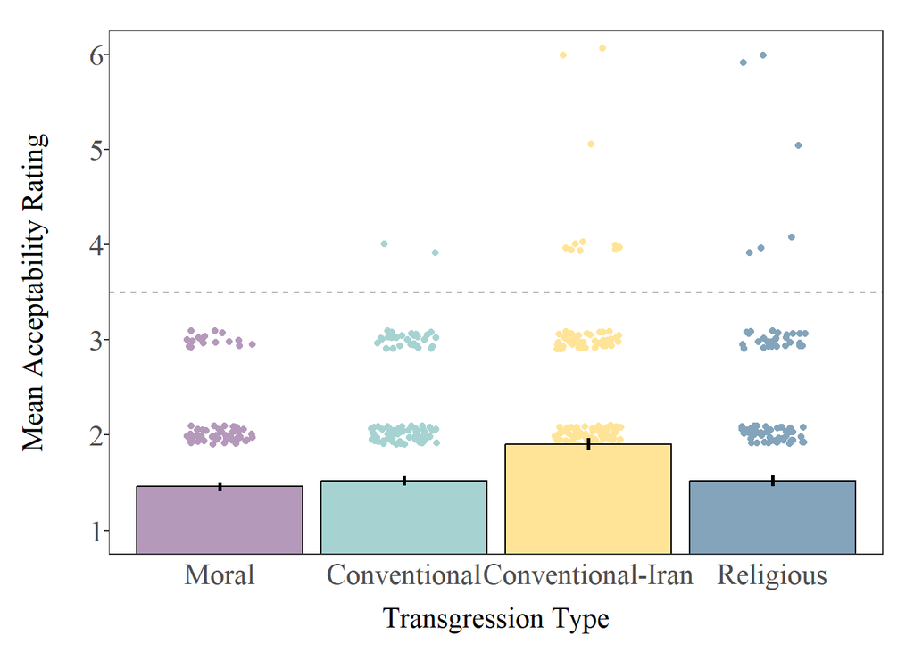

```r
library(ggthemes)
library(viridis)

my.cols <- c("#b499bb", "#a6d3d1", "#ffe498", "#83a4bb")

moral_conventional_figure_3 <- study2_data %>%
  filter(q_kind == 0) %>%
  mutate(task = factor(task, levels = c("moral", "conv", "conv.iran", "religious"),
                       labels = c("Moral", "Conventional", "Conventional-Iran", "Religious")))%>%
  ggplot(aes(x = task, y = answer, fill = task, color = task)) +
  geom_point(position=position_jitter(width = .18, height = .1),
             size=1.5,
             show.legend=FALSE,
             inherit.aes = TRUE) +
  stat_summary(fun = mean, position = position_dodge(width = .9),
               geom="bar", colour = "black") +
  geom_hline(yintercept = 3.5, color = "grey", linetype = "dashed") +
  coord_cartesian(ylim = c(1, 6)) +
  stat_summary(fun.data = "mean_se", geom="linerange",
               position = position_dodge(width=0.9), size = 1, color = "black") +
  theme(legend.position = "none",
        # axis.text.x = element_blank(),
        axis.ticks.x = element_blank(),
        legend.key.size = unit(.5, 'cm'),
        legend.text = element_text(size = 10),
        legend.title = element_text(size = 11),
        legend.margin=margin(t = 0, unit='cm'),
        text = element_text(family = "Times New Roman")) +
  scale_color_manual(values = my.cols) +
  scale_fill_manual(values = my.cols) +
  labs(y = "Mean Acceptability Rating",
       x = "Transgression Type") +
  scale_y_continuous(breaks = c(0, 1, 2, 3, 4, 5, 6))+
    theme(strip.text.x = element_text(size = 16),
        strip.text.y = element_text(size = 16, ),
        axis.text.x = element_text(angle = 0, size = 16, ),
        axis.text.y = element_text(size = 16),
        legend.text = element_text(size = 16),
        legend.title = element_text(size = 16),
        axis.title.x= element_text(vjust = -1, size=16),
        axis.title.y= element_text(vjust = 2.5, size=16),
        legend.position = "none",
        plot.margin=unit(c(6,6,6,6),"mm")) +
  theme(text=element_text(family = "serif")) +
  theme(axis.text.y = element_text(margin = margin(0, 0, 0, 15))) +
  theme(panel.spacing = unit(2, "lines"))
moral_conventional_figure_3
```

### Visualization of ratings by age by task

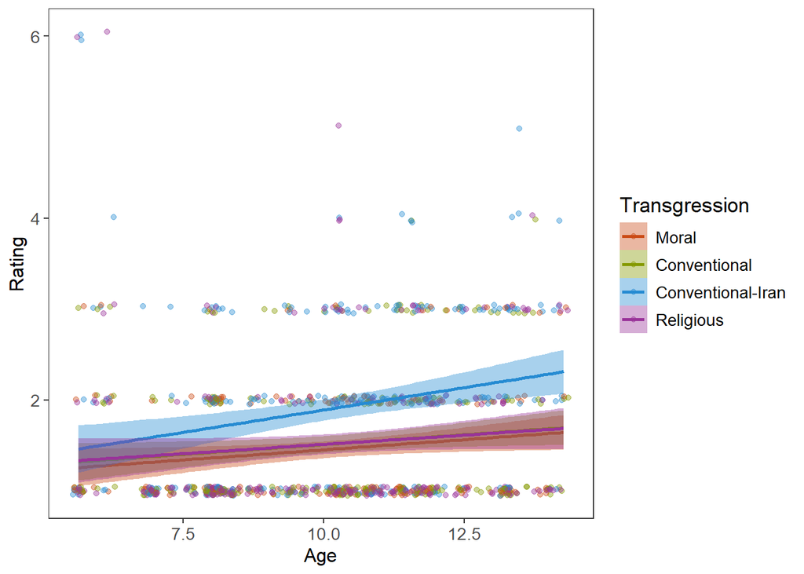

```r
study2_data %>%
  filter(q_kind == 0)%>%
  dplyr::rename("Transgression" = "task")%>%
  mutate(Transgression = factor(Transgression, levels = c("moral", "conv", "conv.iran", "religious"),
                       labels = c("Moral", "Conventional", "Conventional-Iran", "Religious")))%>%
  ggplot(aes(x = age, y= answer, color = Transgression, fill = Transgression)) +
  geom_point(position = position_jitter(width = .1, height = .05),
             alpha = .4) +
  geom_smooth(method ="lm") +
  langcog::scale_color_solarized() +
  langcog::scale_fill_solarized() +
  labs(x = "Age",
       y = "Rating")
```

### Visualization of mean rating (by item) by site

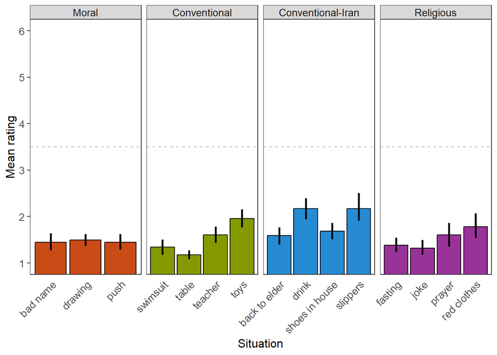

```r
study2_data %>%
  filter(q_kind == 0)%>%
  mutate(task = factor(task, levels = c("moral", "conv", "conv.iran", "religious"),
                       labels = c("Moral", "Conventional", "Conventional-Iran", "Religious")))%>%
  ggplot(aes(x = item, y = answer, fill =task)) +
  stat_summary(fun = mean, position = position_dodge(width = .9),
               geom="bar", colour = "black") +
  geom_hline(yintercept = 3.5, color = "grey", linetype = "dashed") +
  coord_cartesian(ylim = c(1, 6)) +
  facet_grid(~task, scale = "free_x") +
  stat_summary(fun.data = "mean_cl_boot", geom="linerange",
               position = position_dodge(width=0.9), size = 1, color = "black") +
  theme(legend.position = "none",
        axis.text.x = element_text(hjust = 1, angle = 45),
        axis.ticks.x = element_blank(),
        legend.key.size = unit(.5, 'cm'),
        legend.text = element_text(size = 10),
        legend.title = element_text(size = 11),
        legend.margin=margin(t = 0, unit='cm')) +
  langcog::scale_color_solarized() +
  langcog::scale_fill_solarized() +
  labs(y = "Mean rating",
       x = "Situation") +
  scale_y_continuous(breaks = seq(1,6, 1))
```

### Analyses of differences in rating between moral and conventional transgressions: Within-country

Pre-registered mixed-effects model: Rating ~ Transgression type (moral; conventional; conv.iran, religious)*Age + (Transgression type|Subject) + (age|item).

We will iteratively remove item slopes, then subject slopes, then will remove item effects altogether if necessary.

### Model: Answer ~ Task + Age + (1|subid)

**Note** Item model will not converge, so this is our only model

```r
#summary of item model
knitr::kable(summary(iran.rating.base)$coef)
```

|  | Estimate | Std. Error | df | t value | Pr(>\|t\|) |
| --- | --- | --- | --- | --- | --- |
| (Intercept) | 1.4603175 | 0.0691986 | 219.07672 | 21.1032771 | 0.0000000 |
| taskconv | 0.0587516 | 0.0715889 | 878.05376 | 0.8206802 | 0.4120512 |
| taskconv.iran | 0.4444444 | 0.0715246 | 878.00161 | 6.2138647 | 0.0000000 |
| taskreligious | 0.0595238 | 0.0715246 | 878.00161 | 0.8322140 | 0.4055144 |
| age.c | 0.1302533 | 0.0494984 | 60.96852 | 2.6314613 | 0.0107528 |

```r
## pairwise comparisons
emmeans::emmeans(iran.rating.base, pairwise~task, adjust = "none")
```

```
## $emmeans
##  task      emmean     SE  df lower.CL upper.CL
##  moral       1.46 0.0692 219     1.32     1.60
##  conv        1.52 0.0638 163     1.39     1.64
##  conv.iran   1.90 0.0637 162     1.78     2.03
##  religious   1.52 0.0637 162     1.39     1.65
##
## Degrees-of-freedom method: kenward-roger
## Confidence level used: 0.95
##
## $contrasts
##  contrast               estimate     SE  df t.ratio p.value
##  moral - conv          -0.058752 0.0716 878  -0.821  0.4121
##  moral - conv.iran     -0.444444 0.0715 878  -6.214  <.0001
##  moral - religious     -0.059524 0.0715 878  -0.832  0.4055
##  conv - conv.iran      -0.385693 0.0663 878  -5.818  <.0001
##  conv - religious      -0.000772 0.0663 878  -0.012  0.9907
##  conv.iran - religious  0.384921 0.0662 878   5.813  <.0001
##
## Degrees-of-freedom method: kenward-roger
```

```r
study2_data %>%
  filter(q_kind != 0)%>%
  group_by(task, q_kind_label)%>%
  summarise_at('answer',
               list(~mean(., na.rm=T),
                    ~sd(., na.rm=T),
                    ~sum(!is.na(.))))%>%
  dplyr::rename("n" = "sum")%>%
  dplyr::select(task, q_kind_label, n, mean, sd)%>%
  knitr::kable()
```

| task | q_kind_label | n | mean | sd |
| --- | --- | --- | --- | --- |
| conv | Everyone else | 249 | 0.2570281 | 0.4378752 |
| conv | Faraway country | 251 | 0.2071713 | 0.4060891 |
| conv | Foreigner | 251 | 0.1633466 | 0.3704202 |
| conv | Haram | 251 | 0.4223108 | 0.4949144 |
| conv | Illegal | 251 | 0.4940239 | 0.5009632 |
| conv | Non-Muslim | 250 | 0.1400000 | 0.3476831 |
| conv | Rule at school | 251 | 0.3306773 | 0.4713970 |
| conv | Zesht | 251 | 0.9561753 | 0.2051139 |
| conv.iran | Everyone else | 252 | 0.3293651 | 0.4709180 |
| conv.iran | Faraway country | 252 | 0.3134921 | 0.4648357 |
| conv.iran | Foreigner | 252 | 0.3412698 | 0.4750793 |
| conv.iran | Haram | 250 | 0.3560000 | 0.4797757 |
| conv.iran | Illegal | 252 | 0.2896825 | 0.4545177 |
| conv.iran | Non-Muslim | 252 | 0.2857143 | 0.4526530 |
| conv.iran | Rule at school | 252 | 0.4087302 | 0.4925776 |
| conv.iran | Zesht | 252 | 0.9087302 | 0.3020567 |
| moral | Everyone else | 189 | 0.1322751 | 0.3396895 |
| moral | Faraway country | 189 | 0.1375661 | 0.3453589 |
| moral | Foreigner | 189 | 0.1216931 | 0.3277994 |
| moral | Haram | 189 | 0.4708995 | 0.5004782 |
| moral | Illegal | 188 | 0.5000000 | 0.5013351 |
| moral | Non-Muslim | 189 | 0.0952381 | 0.2943232 |
| moral | Rule at school | 189 | 0.2116402 | 0.4095560 |
| moral | Zesht | 252 | 0.9920635 | 0.0889094 |
| religious | Everyone else | 251 | 0.1434263 | 0.3512074 |
| religious | Faraway country | 252 | 0.3412698 | 0.4750793 |
| religious | Foreigner | 252 | 0.3452381 | 0.4763920 |
| religious | Haram | 251 | 0.7330677 | 0.4432405 |
| religious | Illegal | 252 | 0.6150794 | 0.4875449 |
| religious | Non-Muslim | 252 | 0.3809524 | 0.4865873 |
| religious | Rule at school | 250 | 0.3440000 | 0.4759940 |
| religious | Zesht | 189 | 0.8994709 | 0.3015029 |

### Visualization of permissibility by task

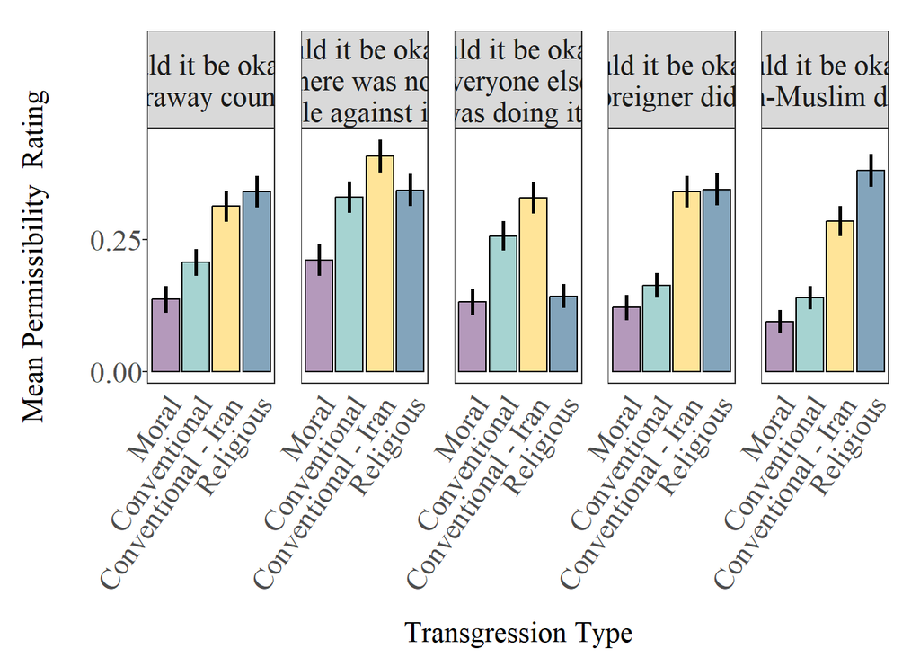

```r
moral_conventional_figure_4 <- study2_data %>%
  filter(q_kind != 0,
         q_kind_label != "Haram",
           q_kind_label != "Illegal",
           q_kind_label != "Zesht")%>%
  mutate(task = factor(task, levels = c("moral", "conv", "conv.iran", "religious"),
                       labels = c("Moral", "Conventional", "Conventional - Iran", "Religious")),
         q_kind_label = ifelse(q_kind_label == "Rule at school",
                               "No rule against it", as.character(q_kind_label)),
         q_kind_label = factor(q_kind_label,
                               levels = c("Faraway country",
                                          "No rule against it",
                                          "Everyone else",
                                          "Foreigner",
                                          "Non-Muslim"),
                               labels = c("Would it be okay in \na faraway country?",
                                          "Would it be okay if \nthere was no \nrule against it?",
                                          "Would it be okay if \neveryone else \nwas doing it?",
                                          "Would it be okay if \na foreigner did it?",
                                          "Would it be okay if \na non-Muslim did it?")))%>%
  ggplot(aes(x = task, y = answer, fill = task, color = task)) +
  stat_summary(fun = mean, position = position_dodge(width = .9),
               geom="bar", colour = "black") +
  stat_summary(fun.data = "mean_se", geom="linerange",
               position = position_dodge(width=0.9), size = 1, color = "black") +
  facet_grid(~q_kind_label) +
theme(legend.position = "none",
        axis.ticks.x = element_blank(),
        legend.key.size = unit(.5, 'cm'),
        legend.text = element_text(size = 10),
        legend.title = element_text(size = 11),
        legend.margin=margin(t = 0, unit='cm'),
        text = element_text(family = "Times New Roman")) +
  scale_color_manual(values = my.cols) +
  scale_fill_manual(values = my.cols) +
  labs(y = "Mean Permissibility  Rating",
       x = "Transgression Type") +
  scale_y_continuous(breaks = c(0, 0.25, 0.5)) +
    theme(strip.text.x = element_text(size = 16),
        strip.text.y = element_text(size = 16, ),
        axis.text.x = element_text(size = 16, angle = 55, hjust = 1, vjust = 1),
        axis.text.y = element_text(size = 16),
        legend.text = element_text(size = 16),
        legend.title = element_text(size = 16),
        axis.title.x= element_text(vjust = -2.5, size=16),
        axis.title.y= element_text(vjust = 2.5, size=16),
        legend.position = "none",
        plot.margin=unit(c(6,6,6,6),"mm")) +
  theme(text=element_text(family = "serif")) +
  theme(axis.text.y = element_text(margin = margin(0, 0, 0, 15))) +
  theme(panel.spacing = unit(1, "lines"))

moral_conventional_figure_4
```

### Visualization of illegal, haram, zesht

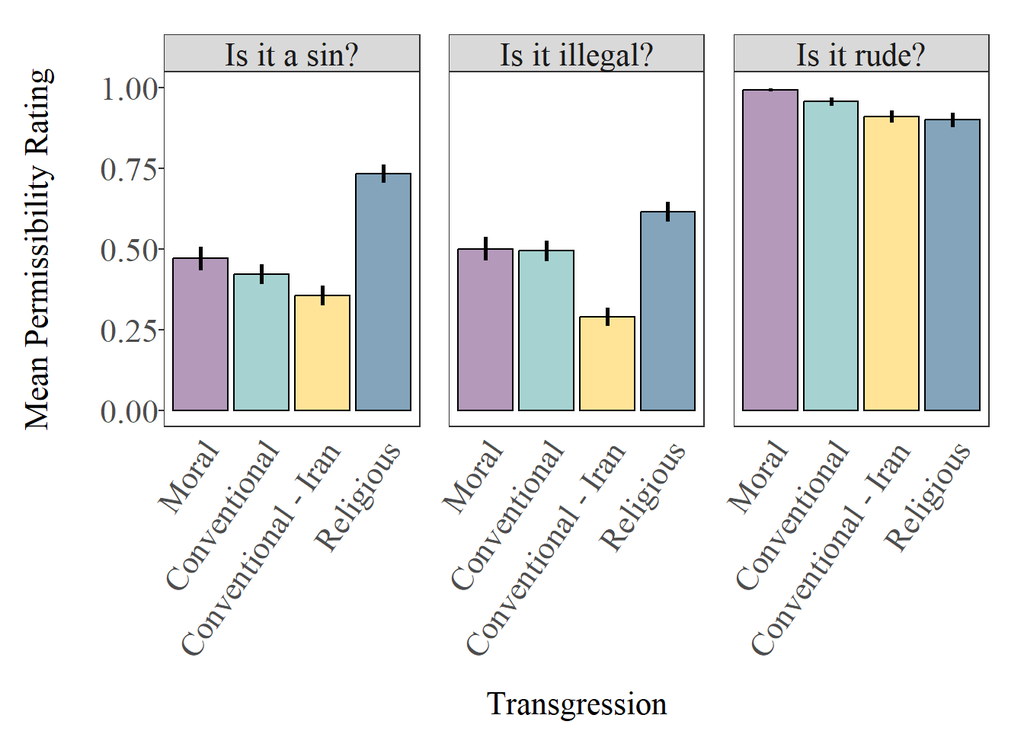

```r
moral_conventional_figure_5 <- study2_data %>%
  filter(q_kind != 0,
         q_kind_label == "Haram" |
           q_kind_label == "Illegal" |
           q_kind_label == "Zesht")%>%
  mutate(task = factor(task, levels = c("moral", "conv", "conv.iran", "religious"),
                       labels = c("Moral", "Conventional", "Conventional - Iran", "Religious")),
         q_kind_label = ifelse(q_kind_label == "Haram", "A sin",
                                      ifelse(q_kind_label == "Zesht", "Rude", "Illegal"))) %>%
  mutate(q_kind_label = factor(q_kind_label,
                               levels = c("A sin", "Illegal", "Rude"),
                               labels = c("Is it a sin?",
                                          "Is it illegal?",
                                          "Is it rude?"))) %>%
  ggplot(aes(x = task, y = answer, fill = task, color = task)) +
  stat_summary(fun = mean, position = position_dodge(width = .9),
               geom="bar", colour = "black") +
  stat_summary(fun.data = "mean_se", geom="linerange",
               position = position_dodge(width=0.9), size = 1, color = "black") +
  facet_grid(~q_kind_label)+
theme(legend.position = "none",
        axis.ticks.x = element_blank(),
        legend.key.size = unit(.5, 'cm'),
        legend.text = element_text(size = 10),
        legend.title = element_text(size = 11),
        legend.margin=margin(t = 0, unit='cm'),
        text = element_text(family = "Times New Roman")) +
  scale_color_manual(values = my.cols) +
  scale_fill_manual(values = my.cols) +
  scale_y_continuous(breaks = c(0, 0.25, 0.5, 0.75, 1.0))+
    theme(strip.text.x = element_text(size = 16),
        strip.text.y = element_text(size = 16, ),
        axis.text.x = element_text(size = 16, angle = 55, hjust = 1, vjust = 1),
        axis.text.y = element_text(size = 16),
        legend.text = element_text(size = 16),
        legend.title = element_text(size = 16),
        axis.title.x= element_text(vjust = -2.5, size=16),
        axis.title.y= element_text(vjust = 2.5, size=16),
        legend.position = "none",
        plot.margin=unit(c(6,6,6,6),"mm")) +
  theme(text=element_text(family = "serif")) +
  theme(axis.text.y = element_text(margin = margin(0, 0, 0, 15))) +
  theme(panel.spacing = unit(1, "lines")) +
  labs(y = "Mean Permissibility Rating",
       x = "Transgression")


## MM: commented following two lines out 9/24/2024
  # langcog::scale_color_solarized() +
  # langcog::scale_fill_solarized() +

  # scale_color_hc("darkunica") +
# +
# +
# ggsave("study2_acceptability_ratings_supp.png", height = 3, width = 8.5)

moral_conventional_figure_5
```

### Analysis of acceptability ratings by transgression type: Within-country:

Pre-registration: Response (yes/no) ~ Transgression type (moral; conventional; conventional-Iran; religious) *Age + (transgression type|subject) +(age|item). Once again we will begin with a maximal random effects structure, and iteratively remove coefficients until the model converges. We will begin first by removing the slope of the item effect, then of subject, and if necessary removing the item effect altogether.

#### If everyone else were doing it: Answer ~ Task + Age + (1|subid)

**Note** Model will not converge with item random effect.

1. Interaction between task and age not significant, so dropped from the model ($\chi^{2}$ = 6.14, *p* = 0.10)
2. Significant difference in acceptability between moral and conventional ($\beta$ = 1.26, *p* < .001)
3. Significant difference in acceptability between moral and conventional-Iran ($\beta$ = 1.84, *p* < .001)
4. No significant difference in acceptability between moral and religious ($\beta$ = .13, *p* = .70)
5. Significant effect of age ($\beta$ = 0.92, *p* < .001)

```r
##summary of main effects
knitr::kable(summary(everyone.base)$coef)
```

|  | Estimate | Std. Error | z value | Pr(>\|z\|) |
| --- | --- | --- | --- | --- |
| (Intercept) | -3.0283682 | 0.3830474 | -7.9059879 | 0.0000000 |
| taskconv | 1.2625036 | 0.3248788 | 3.8860760 | 0.0001019 |
| taskconv.iran | 1.8417229 | 0.3252234 | 5.6629479 | 0.0000000 |
| taskreligious | 0.1323504 | 0.3403705 | 0.3888423 | 0.6973928 |
| age.c | 0.9244460 | 0.2649815 | 3.4887187 | 0.0004853 |

#### Far away: Answer ~ Task + Age + (1|subid)

**Note** Model will not converge with item random effect.

1. Interaction between task and age not significant, so dropped from the model ($\chi^{2}$ = 4.00, *p* = 0.26)
2. Significant difference in acceptability between moral and conventional ($\beta$ = .69, *p* = .03)
3. Significant difference in acceptability between moral and conventional-Iran ($\beta$ = 1.51, *p* < .001)
4. Significant difference in acceptability between moral and religious ($\beta$ = 1.70, *p* < .001)
5. Significant effect of age ($\beta$ = 0.70, *p* = .002)

```r
##summary of main effects
knitr::kable(summary(faraway.base)$coef)
```

|  | Estimate | Std. Error | z value | Pr(>\|z\|) |
| --- | --- | --- | --- | --- |
| (Intercept) | -2.6612094 | 0.3333467 | -7.983309 | 0.0000000 |
| taskconv | 0.6910018 | 0.3117990 | 2.216177 | 0.0266794 |
| taskconv.iran | 1.5139795 | 0.3054533 | 4.956501 | 0.0000007 |
| taskreligious | 1.7028893 | 0.3055509 | 5.573178 | 0.0000000 |
| age.c | 0.6963177 | 0.2215266 | 3.143269 | 0.0016707 |

#### Rule at school: Answer ~ Task + Age + (1|subid)

**Note** Model will not converge with item random effect.

1. Interaction between task and age not significant, so dropped from the model ($\chi^{2}$ = 1.08, *p* = 0.78)
2. Significant difference in acceptability between moral and conventional ($\beta$ = .91, *p* < .001)
3. Significant difference in acceptability between moral and conventional-Iran ($\beta$ = 1.45, *p* < .001)
4. Significant difference in acceptability between moral and religious ($\beta$ = 1.00, *p* < .001)
5. Significant effect of age ($\beta$ = 0.73, *p* = .002)

```r
##summary of main effects
knitr::kable(summary(rule.base)$coef)
```

|  | Estimate | Std. Error | z value | Pr(>\|z\|) |
| --- | --- | --- | --- | --- |
| (Intercept) | -2.0427006 | 0.3029816 | -6.741995 | 0.0000000 |
| taskconv | 0.9110166 | 0.2688117 | 3.389051 | 0.0007014 |
| taskconv.iran | 1.4486352 | 0.2695952 | 5.373371 | 0.0000001 |
| taskreligious | 0.9999560 | 0.2688151 | 3.719865 | 0.0001993 |
| age.c | 0.7345514 | 0.2251618 | 3.262328 | 0.0011050 |

#### Foreigner: Answer ~ Task + Age +Task:Age + (1|subid)

**Note** Model will not converge with item random effect.

```r
##summary of main effects
car::Anova(foreigner, type = "III")
```

```
## Analysis of Deviance Table (Type III Wald chisquare tests)
##
## Response: answer
##               Chisq Df Pr(>Chisq)
## (Intercept) 62.6489  1   2.47e-15 ***
## task        53.0950  3   1.75e-11 ***
## age.c        3.5921  1   0.058054 .
## task:age.c  12.3195  3   0.006365 **
## ---
## Signif. codes:  0 '***' 0.001 '**' 0.01 '*' 0.05 '.' 0.1 ' ' 1
```

```r
knitr::kable(summary(foreigner)$coef)
```

|  | Estimate | Std. Error | z value | Pr(>\|z\|) |
| --- | --- | --- | --- | --- |
| (Intercept) | -3.0498633 | 0.3853217 | -7.9151085 | 0.0000000 |
| taskconv | 0.5387189 | 0.3524709 | 1.5284068 | 0.1264116 |
| taskconv.iran | 2.0114597 | 0.3432397 | 5.8602193 | 0.0000000 |
| taskreligious | 1.8946882 | 0.3505020 | 5.4056424 | 0.0000001 |
| age.c | 0.6743610 | 0.3558087 | 1.8952909 | 0.0580539 |
| taskconv:age.c | -0.1739949 | 0.3278794 | -0.5306673 | 0.5956493 |
| taskconv.iran:age.c | 0.0338042 | 0.3189454 | 0.1059873 | 0.9155924 |
| taskreligious:age.c | 0.7808789 | 0.3407673 | 2.2915314 | 0.0219327 |

#### Non-Muslim: Answer ~ Task + Age + Task:Age + (1|subid)

**Note** Model will not converge with item random effect.

1. Significant interaction between task and age ($\chi^{2}$ = 15.37, *p* = .002)
2. No significant difference in acceptability between moral and conventional ($\beta$ = .40, *p* =.30)
3. Significant difference in acceptability between moral and conventional-Iran ($\beta$ = 1.77, *p* < .001)
4. Significant difference in acceptability between moral and religious ($\beta$ = 2.38, *p* < .001)
5. No effect of age ($\beta$ = -0.08, *p* = .83)
6. Significant interaction between age and conventional items ($\beta$ = 0.85, *p* = .03)
7. Significant interaction between age and conventional-Iran items ($\beta$ = .77, *p* =.03)
8. Significant interaction between age and religious items ($\beta$ = 1.38, *p* < .001)

```r
##summary of main effects
car::Anova(muslim, type = "III")
```

```
## Analysis of Deviance Table (Type III Wald chisquare tests)
##
## Response: answer
##               Chisq Df Pr(>Chisq)
## (Intercept) 68.3236  1  < 2.2e-16 ***
## task        63.6497  3  9.753e-14 ***
## age.c        0.0439  1   0.833955
## task:age.c  15.0614  3   0.001765 **
## ---
## Signif. codes:  0 '***' 0.001 '**' 0.01 '*' 0.05 '.' 0.1 ' ' 1
```

```r
knitr::kable(summary(muslim)$coef)
```

|  | Estimate | Std. Error | z value | Pr(>\|z\|) |
| --- | --- | --- | --- | --- |
| (Intercept) | -3.2468559 | 0.3928056 | -8.2658082 | 0.0000000 |
| taskconv | 0.3863518 | 0.3754228 | 1.0291110 | 0.3034275 |
| taskconv.iran | 1.7705881 | 0.3468256 | 5.1051246 | 0.0000003 |
| taskreligious | 2.3718115 | 0.3559588 | 6.6631627 | 0.0000000 |
| age.c | -0.0784758 | 0.3743516 | -0.2096312 | 0.8339555 |
| taskconv:age.c | 0.8466160 | 0.3817512 | 2.2177168 | 0.0265742 |
| taskconv.iran:age.c | 0.7749227 | 0.3442693 | 2.2509204 | 0.0243906 |
| taskreligious:age.c | 1.3763660 | 0.3597774 | 3.8256040 | 0.0001305 |

#### Haram: Answer ~ Task + Age + (1|subid)

**Note** Model will not converge with item random effect.

1. No significant interaction between task and age ($\chi^{2}$ = 5.59, *p* = .13)
2. No significant difference between moral and conventional ($\beta$ = -0.41, *p* =.14)
3. Significant difference between moral and conventional-Iran ($\beta$ = -1.01, *p* < .001)
4. Significant difference between moral and religious ($\beta$ = 2.02, *p* < .001)
5. Significant effect of age ($\beta$ = -1.31, *p* < .001)

```r
##summary of main effects
knitr::kable(summary(haram.base)$coef)
```

|  | Estimate | Std. Error | z value | Pr(>\|z\|) |
| --- | --- | --- | --- | --- |
| (Intercept) | 1.987245 | 0.3231921 | 6.148803 | 0.0e+00 |
| taskconv | -2.427794 | 0.2832067 | -8.572517 | 0.0e+00 |
| taskconv.iran | -3.036767 | 0.3041000 | -9.986078 | 0.0e+00 |
| taskmoral | -2.019639 | 0.2905966 | -6.949974 | 0.0e+00 |
| age.c | -1.305176 | 0.2763701 | -4.722568 | 2.3e-06 |

#### Illegal: Answer ~ Task + Age + (1|subid)

**Note** Model will not converge with item random effect.

1. No significant interaction between task and age ($\chi^{2}$ = 1.37, *p* = .71)
2. No significant difference between moral and conventional ($\beta$ = -0.03, *p* =.90)
3. Significant difference between moral and conventional-Iran ($\beta$ = -1.50, *p* < .001)
4. Significant difference moral and religious ($\beta$ = 0.78, *p* = .002)
5. Significant effect of age ($\beta$ = -1.12, *p* < .001)

```r
##summary of main effects
knitr::kable(summary(illegal.base)$coef)
```

|  | Estimate | Std. Error | z value | Pr(>\|z\|) |
| --- | --- | --- | --- | --- |
| (Intercept) | 0.0751131 | 0.2918079 | 0.2574058 | 0.7968655 |
| taskconv | -0.0301131 | 0.2439420 | -0.1234436 | 0.9017558 |
| taskconv.iran | -1.5019040 | 0.2654639 | -5.6576577 | 0.0000000 |
| taskreligious | 0.7753519 | 0.2470881 | 3.1379568 | 0.0017013 |
| age.c | -1.1190982 | 0.2496480 | -4.4827050 | 0.0000074 |

#### Zesht: Answer ~ Task + Age + (1|subid)

**Note** Model will not converge with item random effect.

1. No significant interaction between task and age ($\chi^{2}$ = 1.37, *p* = .71)
2. Significant difference between moral and conventional ($\beta$ = -1.87, *p* =.02)
3. Significant difference between moral and conventional-Iran ($\beta$ = -2.85, *p* < .001)
4. Significant difference between moral and religious ($\beta$ = -2.93, *p* < .001)
5. Significant effect of age ($\beta$ = -0.54, *p* = .02)

```r
##summary of main effects
knitr::kable(summary(zesht.base)$coef)
```

|  | Estimate | Std. Error | z value | Pr(>\|z\|) |
| --- | --- | --- | --- | --- |
| (Intercept) | 2.9760289 | 0.3556890 | 8.366940 | 0.0000000 |
| taskconv | 0.9801606 | 0.4080581 | 2.402013 | 0.0163051 |
| taskmoral | 2.8522770 | 0.7661580 | 3.722831 | 0.0001970 |
| taskreligious | -0.0730787 | 0.3570980 | -0.204646 | 0.8378487 |
| age.c | -0.5400336 | 0.2388129 | -2.261325 | 0.0237391 |

## Now we need to look at how acceptability differs under different circumstances

### … first is faraway, everyone, rule, foreigner, and muslim

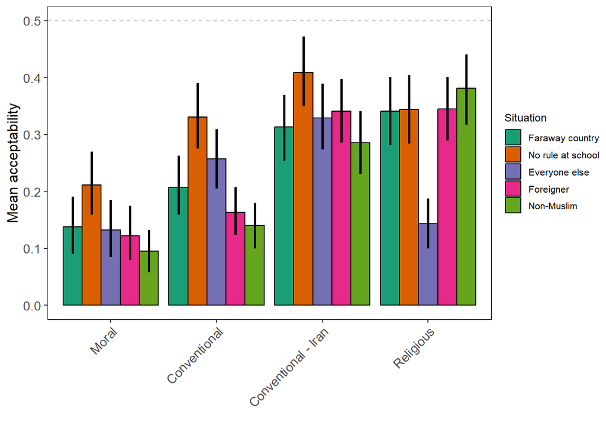

```r
acceptability.limited <- acceptability.ms %>%
  filter(q_kind_label != "Illegal",
         q_kind_label != "Haram",
         q_kind_label != "Zesht")


#### visualization
acceptability.limited %>%
  mutate(q_kind_label = ifelse (q_kind_label == "Rule at school",
                                "No rule at school", as.character(q_kind_label)),
         q_kind_label = factor(q_kind_label, levels = c("Faraway country",
                                                        "No rule at school",
                                                        "Everyone else",
                                                        "Foreigner",
                                                        "Non-Muslim")))%>%
  mutate(task = factor(task, levels = c("moral", "conv", "conv.iran", "religious"),
                       labels = c("Moral", "Conventional",
                                  "Conventional - Iran", "Religious")))%>%
  ggplot(aes(x = task, y = answer, fill = q_kind_label)) +
  stat_summary(fun = mean, position = position_dodge(width = .9),
               geom="bar", colour = "black") +
  stat_summary(fun.data = "mean_cl_boot", geom="linerange",
               position = position_dodge(width=0.9), size = 1, color = "black") +
  geom_hline(yintercept = .5, color = "grey", linetype = "dashed") +
  theme(legend.position = "right",
        legend.key.size = unit(.5, 'cm'),
        legend.text = element_text(size = 8),
        legend.title = element_text(size = 9),
        legend.margin=margin(t = 0, unit='cm'),
        axis.text.x = element_text(hjust = 1, angle = 45),
         text = element_text(family = "Times New Roman")) +
  scale_fill_brewer(palette = "Dark2") +
  labs(y = "Mean acceptability",
       x = "",
       fill = "Situation")
```

```r
ggsave("circumstances_study2.png", height = 3.5, width = 8)
## Now run some analyses
######## Moral items first ########
iran.circumstances.base <- glmer(answer ~ age.c + (1|subid),
                                 family = "binomial",
                                 data = subset(acceptability.limited, task == "moral"))
## add q kind
iran.circumstances <- glmer(answer ~ q_kind_label + age.c + (1|subid),
                                 family = "binomial",
                                 data = subset(acceptability.limited, task == "moral"))
anova(iran.circumstances.base, iran.circumstances, test = 'lrt') #significant effect of circumstances, chisq = 16.724
```

```
## Data: subset(acceptability.limited, task == "moral")
## Models:
## iran.circumstances.base: answer ~ age.c + (1 | subid)
## iran.circumstances: answer ~ q_kind_label + age.c + (1 | subid)
##                         npar    AIC    BIC  logLik deviance  Chisq Df
## iran.circumstances.base    3 602.53 617.09 -298.27   596.53
## iran.circumstances         7 593.81 627.77 -289.90   579.81 16.724  4
##                         Pr(>Chisq)
## iran.circumstances.base
## iran.circumstances        0.002187 **
## ---
## Signif. codes:  0 '***' 0.001 '**' 0.01 '*' 0.05 '.' 0.1 ' ' 1
```

```r
emmeans::emmeans(iran.circumstances, pairwise~q_kind_label, adjust = "none")
```

```
## $emmeans
##  q_kind_label    emmean    SE  df asymp.LCL asymp.UCL
##  Everyone else    -3.61 0.562 Inf     -4.71     -2.51
##  Faraway country  -3.54 0.559 Inf     -4.64     -2.45
##  Foreigner        -3.75 0.568 Inf     -4.86     -2.63
##  Non-Muslim       -4.13 0.585 Inf     -5.28     -2.98
##  Rule at school   -2.73 0.528 Inf     -3.77     -1.70
##
## Results are given on the logit (not the response) scale.
## Confidence level used: 0.95
##
## $contrasts
##  contrast                         estimate    SE  df z.ratio p.value
##  Everyone else - Faraway country   -0.0663 0.364 Inf  -0.182  0.8554
##  Everyone else - Foreigner          0.1379 0.371 Inf   0.371  0.7104
##  Everyone else - (Non-Muslim)       0.5215 0.389 Inf   1.341  0.1800
##  Everyone else - Rule at school    -0.8749 0.348 Inf  -2.514  0.0119
##  Faraway country - Foreigner        0.2042 0.369 Inf   0.553  0.5802
##  Faraway country - (Non-Muslim)     0.5878 0.387 Inf   1.519  0.1288
##  Faraway country - Rule at school  -0.8085 0.345 Inf  -2.341  0.0192
##  Foreigner - (Non-Muslim)           0.3836 0.393 Inf   0.975  0.3294
##  Foreigner - Rule at school        -1.0127 0.354 Inf  -2.860  0.0042
##  (Non-Muslim) - Rule at school     -1.3964 0.374 Inf  -3.730  0.0002
##
## Results are given on the log odds ratio (not the response) scale.
```

```r
## rule contingency effect for moral items - much more likely to

######## conventional ########
iran.circumstances.base.conv <- glmer(answer ~ age.c + (1|subid),
                                 family = "binomial",
                                 data = subset(acceptability.limited, task == "conv"))
## add q kind
iran.circumstances.conv <- glmer(answer ~ q_kind_label + age.c + (1|subid),
                                 family = "binomial",
                                 data = subset(acceptability.limited, task == "conv"))
anova(iran.circumstances.base.conv, iran.circumstances.conv, test = 'lrt') #significant effect of circumstances, chisq = 52.276
```

```
## Data: subset(acceptability.limited, task == "conv")
## Models:
## iran.circumstances.base.conv: answer ~ age.c + (1 | subid)
## iran.circumstances.conv: answer ~ q_kind_label + age.c + (1 | subid)
##                              npar     AIC    BIC  logLik deviance  Chisq Df
## iran.circumstances.base.conv    3 1009.98 1025.4 -501.99  1003.98
## iran.circumstances.conv         7  965.71 1001.6 -475.85   951.71 52.276  4
##                              Pr(>Chisq)
## iran.circumstances.base.conv
## iran.circumstances.conv       1.208e-10 ***
## ---
## Signif. codes:  0 '***' 0.001 '**' 0.01 '*' 0.05 '.' 0.1 ' ' 1
```

```r
emmeans::emmeans(iran.circumstances.conv, pairwise~q_kind_label, adjust = "none")
```

```
## $emmeans
##  q_kind_label    emmean    SE  df asymp.LCL asymp.UCL
##  Everyone else    -2.00 0.349 Inf     -2.68    -1.314
##  Faraway country  -2.44 0.358 Inf     -3.14    -1.739
##  Foreigner        -2.88 0.370 Inf     -3.60    -2.153
##  Non-Muslim       -3.14 0.378 Inf     -3.88    -2.402
##  Rule at school   -1.40 0.336 Inf     -2.05    -0.736
##
## Results are given on the logit (not the response) scale.
## Confidence level used: 0.95
##
## $contrasts
##  contrast                         estimate    SE  df z.ratio p.value
##  Everyone else - Faraway country     0.444 0.268 Inf   1.653  0.0983
##  Everyone else - Foreigner           0.880 0.279 Inf   3.153  0.0016
##  Everyone else - (Non-Muslim)        1.146 0.288 Inf   3.979  0.0001
##  Everyone else - Rule at school     -0.602 0.258 Inf  -2.336  0.0195
##  Faraway country - Foreigner         0.437 0.283 Inf   1.542  0.1230
##  Faraway country - (Non-Muslim)      0.702 0.291 Inf   2.412  0.0159
##  Faraway country - Rule at school   -1.046 0.266 Inf  -3.931  0.0001
##  Foreigner - (Non-Muslim)            0.266 0.299 Inf   0.889  0.3738
##  Foreigner - Rule at school         -1.483 0.278 Inf  -5.325  <.0001
##  (Non-Muslim) - Rule at school      -1.748 0.288 Inf  -6.070  <.0001
##
## Results are given on the log odds ratio (not the response) scale.
```

```r
######## conventional - iran ########
iran.circumstances.base.conv.iran <- glmer(answer ~ age.c + (1|subid),
                                 family = "binomial",
                                 data = subset(acceptability.limited, task == "conv.iran"))
## add q kind
iran.circumstances.conv.iran <- glmer(answer ~ q_kind_label + age.c + (1|subid),
                                 family = "binomial",
                                 data = subset(acceptability.limited, task == "conv.iran"))
anova(iran.circumstances.base.conv.iran, iran.circumstances.conv.iran, test = 'lrt') #significant effect of circumstances, chisq = 13.401
```

```
## Data: subset(acceptability.limited, task == "conv.iran")
## Models:
## iran.circumstances.base.conv.iran: answer ~ age.c + (1 | subid)
## iran.circumstances.conv.iran: answer ~ q_kind_label + age.c + (1 | subid)
##                                   npar    AIC    BIC  logLik deviance  Chisq Df
## iran.circumstances.base.conv.iran    3 1328.6 1344.0 -661.32   1322.6
## iran.circumstances.conv.iran         7 1323.2 1359.2 -654.62   1309.2 13.401  4
##                                   Pr(>Chisq)
## iran.circumstances.base.conv.iran
## iran.circumstances.conv.iran        0.009474 **
## ---
## Signif. codes:  0 '***' 0.001 '**' 0.01 '*' 0.05 '.' 0.1 ' ' 1
```

```r
emmeans::emmeans(iran.circumstances.conv.iran, pairwise~q_kind_label, adjust = "none")
```

```
## $emmeans
##  q_kind_label    emmean    SE  df asymp.LCL asymp.UCL
##  Everyone else   -1.058 0.247 Inf     -1.54   -0.5732
##  Faraway country -1.161 0.249 Inf     -1.65   -0.6737
##  Foreigner       -0.982 0.246 Inf     -1.46   -0.4989
##  Non-Muslim      -1.348 0.252 Inf     -1.84   -0.8542
##  Rule at school  -0.565 0.242 Inf     -1.04   -0.0907
##
## Results are given on the logit (not the response) scale.
## Confidence level used: 0.95
##
## $contrasts
##  contrast                         estimate    SE  df z.ratio p.value
##  Everyone else - Faraway country    0.1033 0.224 Inf   0.461  0.6445
##  Everyone else - Foreigner         -0.0762 0.222 Inf  -0.343  0.7314
##  Everyone else - (Non-Muslim)       0.2898 0.227 Inf   1.279  0.2008
##  Everyone else - Rule at school    -0.4924 0.220 Inf  -2.243  0.0249
##  Faraway country - Foreigner       -0.1795 0.223 Inf  -0.804  0.4212
##  Faraway country - (Non-Muslim)     0.1865 0.228 Inf   0.819  0.4126
##  Faraway country - Rule at school  -0.5958 0.221 Inf  -2.696  0.0070
##  Foreigner - (Non-Muslim)           0.3660 0.226 Inf   1.620  0.1052
##  Foreigner - Rule at school        -0.4162 0.219 Inf  -1.904  0.0569
##  (Non-Muslim) - Rule at school     -0.7822 0.224 Inf  -3.491  0.0005
##
## Results are given on the log odds ratio (not the response) scale.
```

```r
######## religious ########
iran.circumstances.base.religious <- glmer(answer ~ age.c + (1|subid),
                                 family = "binomial",
                                 data = subset(acceptability.limited, task == "religious"),
                                  control=glmerControl(optimizer="bobyqa",
                                             optCtrl=list(maxfun=2e4)))
## add q kind
iran.circumstances.religious <- glmer(answer ~ q_kind_label + age.c + (1|subid),
                                 family = "binomial",
                                 data = subset(acceptability.limited, task == "religious"),
                                  control=glmerControl(optimizer="bobyqa",
                                             optCtrl=list(maxfun=2e4)))
anova(iran.circumstances.base.religious, iran.circumstances.religious, test = 'lrt') #significant effect of circumstances, chisq = 69.814
```

```
## Data: subset(acceptability.limited, task == "religious")
## Models:
## iran.circumstances.base.religious: answer ~ age.c + (1 | subid)
## iran.circumstances.religious: answer ~ q_kind_label + age.c + (1 | subid)
##                                   npar    AIC    BIC  logLik deviance  Chisq Df
## iran.circumstances.base.religious    3 1239.3 1254.7 -616.66   1233.3
## iran.circumstances.religious         7 1177.5 1213.5 -581.75   1163.5 69.814  4
##                                   Pr(>Chisq)
## iran.circumstances.base.religious
## iran.circumstances.religious       2.485e-14 ***
## ---
## Signif. codes:  0 '***' 0.001 '**' 0.01 '*' 0.05 '.' 0.1 ' ' 1
```

```r
emmeans::emmeans(iran.circumstances.religious, pairwise~q_kind_label, adjust = "none")
```

```
## $emmeans
##  q_kind_label    emmean    SE  df asymp.LCL asymp.UCL
##  Everyone else   -2.747 0.307 Inf     -3.35    -2.146
##  Faraway country -1.082 0.267 Inf     -1.60    -0.560
##  Foreigner       -1.054 0.266 Inf     -1.58    -0.533
##  Non-Muslim      -0.811 0.264 Inf     -1.33    -0.295
##  Rule at school  -1.067 0.267 Inf     -1.59    -0.544
##
## Results are given on the logit (not the response) scale.
## Confidence level used: 0.95
##
## $contrasts
##  contrast                         estimate    SE  df z.ratio p.value
##  Everyone else - Faraway country   -1.6653 0.271 Inf  -6.140  <.0001
##  Everyone else - Foreigner         -1.6928 0.271 Inf  -6.241  <.0001
##  Everyone else - (Non-Muslim)      -1.9362 0.272 Inf  -7.128  <.0001
##  Everyone else - Rule at school    -1.6806 0.272 Inf  -6.188  <.0001
##  Faraway country - Foreigner       -0.0275 0.230 Inf  -0.120  0.9048
##  Faraway country - (Non-Muslim)    -0.2709 0.229 Inf  -1.185  0.2361
##  Faraway country - Rule at school  -0.0153 0.231 Inf  -0.066  0.9472
##  Foreigner - (Non-Muslim)          -0.2433 0.228 Inf  -1.066  0.2866
##  Foreigner - Rule at school         0.0122 0.230 Inf   0.053  0.9576
##  (Non-Muslim) - Rule at school      0.2556 0.229 Inf   1.116  0.2642
##
## Results are given on the log odds ratio (not the response) scale.
```

## Justifications

```r
# Read in the justification data
justifications <- read.csv("data/raw_data/study2/justifications_updated_6_27_2024.csv") %>%
  filter(justifications != "",
         !is.na(Final.theme))%>%
  mutate(Final.theme = ifelse(Final.theme == " disrespect", "disrespect",
                              ifelse((Final.theme == "religious " | Final.theme == "reliigious"), "religious", as.character(Final.theme))))
```

### …. visualization of theme x frequency

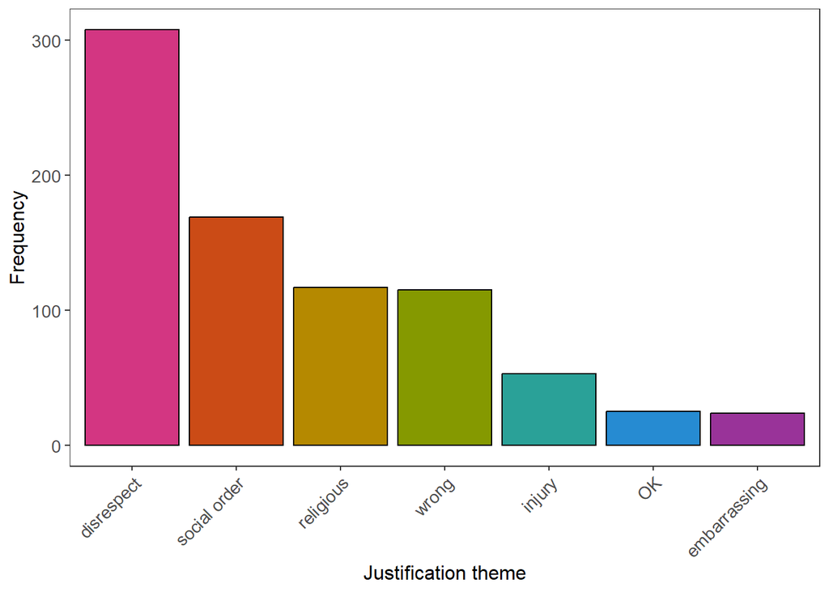

```r
justifications %>%
  group_by(Final.theme)%>%
  summarise(n = n())%>%
  arrange(desc(n))%>%
  mutate(Final.theme = fct_reorder(factor(Final.theme), n, .desc = TRUE))%>%
  ggplot(aes(x = Final.theme, y = n, fill = Final.theme))+
  geom_bar(stat = "identity", color = "black") +
  theme(axis.text.x = element_text(hjust = 1, angle = 45),
        legend.position = "none") +
  labs(x = "Justification theme",
       y = "Frequency") +
  langcog::scale_fill_solarized("Justification theme")
```

### …. visualization of frequency of justification theme for different kinds of items

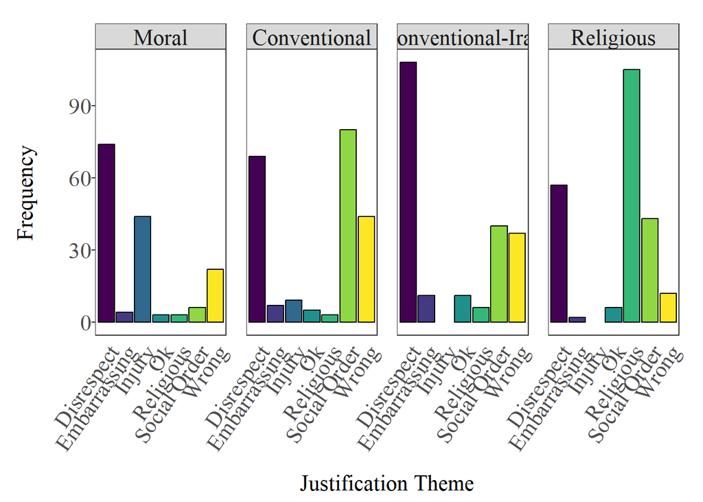

```r
my.cols.2 <- c("#b499bb", "#a6d3d1", "#ffe498", "#83a4bb")


moral <- c("push", "bad name", "drawing")
conventional <- c("table", "swimsuit", "teacher", "toys", "toys ")
conventional_iran <- c("shoes in house", "back to elder", "drink", "slippers")
religious <- c("fasting", "prayer", "red clothes", "joke")

moral_conventional_figure_6 <- justifications %>%
  filter(item != "")%>%
  mutate(transgression = ifelse(item %in% moral, "Moral",
                                ifelse(item %in% conventional, "Conventional",
                                       ifelse(item %in% conventional_iran, "Conventional-Iran", "Religious"))),
         transgression = factor(transgression, levels = c("Moral", "Conventional",
                                                          "Conventional-Iran", "Religious")),
         Final.theme = str_to_title(Final.theme)) %>%
  group_by(transgression, Final.theme)%>%
  summarise(n = n())%>%
  ggplot(aes(x = Final.theme, y = n, fill = Final.theme)) +
  geom_bar(stat = "identity", color = "black") +
  labs(x = "Justification Theme",
       y = "Frequency") +
  facet_grid(~transgression) +
  scale_fill_viridis_d() +
  theme(axis.text.x = element_text(hjust = 1, angle = 45),
        legend.position = "none",
         text = element_text(family = "Times New Roman")) +
  theme(legend.position = "none",
        axis.ticks.x = element_blank(),
        legend.key.size = unit(.5, 'cm'),
        legend.text = element_text(size = 10),
        legend.title = element_text(size = 11),
        legend.margin=margin(t = 0, unit='cm'),
        text = element_text(family = "Times New Roman")) +
  theme(strip.text.x = element_text(size = 16),
        strip.text.y = element_text(size = 16, ),
        axis.text.x = element_text(size = 16, angle = 55, hjust = 1, vjust = 1),
        axis.text.y = element_text(size = 16),
        legend.text = element_text(size = 16),
        legend.title = element_text(size = 16),
        axis.title.x= element_text(vjust = -2.5, size=16),
        axis.title.y= element_text(vjust = 2.5, size=16),
        legend.position = "none",
        plot.margin=unit(c(6,6,6,6),"mm")) +
  theme(text=element_text(family = "serif")) +
  theme(axis.text.y = element_text(margin = margin(0, 0, 0, 15))) +
  theme(panel.spacing = unit(1, "lines")) +
  scale_fill_manual(values = c(viridis::viridis(7))
                                  )
moral_conventional_figure_6
```